**Proceso de selección para el cargo de analista en la Coordinación de Analítica de ProColombia**

# Exportaciones no minero-energéticas (NME): Pronósticos

## Autor

Nicolás Rivera Garzón, nicolas.riveragr@gmail.com

## Contenido

- 1. Objetivo
- 2. Metodología
- 3. Exploración de datos
- 4.1. ARIMA y SARIMA
- 4.2. Algoritmo de Suavizado exponencial triple (ETS))
- 4.3. Prophet
- 4.4. XGBoost
- 5. Medidas de precisión y comparación de pronósticos

## 1. Objetivo

Proyectar las exportaciones no minero-energéticas (NME) para el cierre de 2023 y 2024.

## 2. Metodología

Se realizará el siguiente proceso:

1. Importación de datos desde un directorio que se puede cambiar fácilmente para replicar datos.
2. Análisis exploratorio de datos para encontrar puntos relevantes y características de la serie de tiempo como: estacionalidad y autocorrelación.
3. Construcción de modelos ARIMA, SARIMA, ETS, Prophet y XGBoost.
4. Elección del mejor modelo en el conjunto de validación a partir de las métricas de MAE, MSE y RMSE.
5. Obtención del pronóstico del interés con el modelo elegido.

## 3. Exploración de datos

```python
# Cambiar el directorio de trabajo al lugar donde estén los datos
import os

# Nuevo directorio
data_directory = 'C:\\Users\\Nicolás Rivera\\OneDrive\\Escritorio\\Procolombia\\Datos'
os.chdir(data_directory)

# El sigueinte es el directorio donde se realiza la prueba
os.getcwd()
```

```
'C:\\Users\\Nicolás Rivera\\OneDrive\\Escritorio\\Procolombia\\Datos'
```

```python
## Cargue de librerías
import pandas as pd
import numpy as np
import matplotlib.pyplot as plt
import math
import tqdm as notebook_tqdm

from statsmodels.tsa.seasonal import seasonal_decompose
from statsmodels.graphics.tsaplots import plot_acf, plot_pacf
from statsmodels.tsa.stattools import adfuller
from statsmodels.tsa.arima.model import ARIMA
from statsmodels.tsa.statespace.sarimax import SARIMAX
from sklearn.metrics import mean_absolute_error, mean_squared_error
from statsmodels.tsa.holtwinters import ExponentialSmoothing
from sklearn.linear_model import LinearRegression

# Modelo phophet (pip install fbprophet)
from prophet import Prophet

# Modelo XGBoost (pip install xgboost)
from xgboost import XGBRegressor

# Importar librería para selección de lags (pip install pmdarima)
from pmdarima import auto_arima

## Param
pd.set_option('display.float_format', '{:.2f}'.format)
```

```python
# Importar base de datos
df = pd.read_excel('expo_nme.xlsx')

# Mostrar estructura de los datos
df.head()
```

|  | Mes | Expo_NME |
| --- | --- | --- |
| 0 | 2006-01-01 | 810133312.30 |
| 1 | 2006-02-01 | 969127002.92 |
| 2 | 2006-03-01 | 1071191991.02 |
| 3 | 2006-04-01 | 929687981.83 |
| 4 | 2006-05-01 | 1088814132.41 |

```python
# Transformación de la columna mes

# Convertir la columna Mes a tipo datetime
df.index = pd.to_datetime(df['Mes'], format='%b-%y')

# Eliminar la columna original Mes
df.drop(columns='Mes', inplace=True)

# Crear una nueva columna con el formato YYYY-MM
df['Fecha'] = df.index.strftime('%b-%y')

# Mostrar el DataFrame resultante
df.head()
```

| Mes | Expo_NME | Fecha |
| --- | --- | --- |
| 2006-01-01 | 810133312.30 | Jan-06 |
| 2006-02-01 | 969127002.92 | Feb-06 |
| 2006-03-01 | 1071191991.02 | Mar-06 |
| 2006-04-01 | 929687981.83 | Apr-06 |
| 2006-05-01 | 1088814132.41 | May-06 |

```python
# Verificación de datos nulos
missing_values = df['Expo_NME'].isnull().sum()
print(f'Número de valores nulos: {missing_values}')
```

```
Número de valores nulos: 0
```

```python
# Estadísticas descriptivas
stats_descriptivas = df['Expo_NME'].describe()
print(stats_descriptivas)
```

```
count          213.00
mean    1333884705.31
std      215436413.45
min      810133312.30
25%     1202703657.51
50%     1304598686.00
75%     1419732431.98
max     1995581610.84
Name: Expo_NME, dtype: float64
```

```python
# Estadísticas descriptivas por año
stats_descriptivas_por_año = df.groupby(df.index.year)['Expo_NME'].agg(['count', 'mean', 'min', 'max'])
print(stats_descriptivas_por_año)
```

```
      count          mean           min           max
Mes
2006     12 1064164967.63  810133312.30 1206777279.54
2007     12 1352903448.79  997864398.77 1698625246.62
2008     12 1493152506.42 1325889848.48 1692093676.16
2009     12 1198749363.44 1027718245.02 1380698332.65
2010     12 1149274472.48  975506490.18 1355155132.55
2011     12 1337687880.50 1155135154.64 1608656469.22
2012     12 1341767645.58 1148564747.85 1496682319.55
2013     12 1363224448.20 1225468031.24 1556510085.99
2014     12 1363571253.70 1108641191.47 1528275181.23
2015     12 1255254307.60 1118341765.79 1327530507.75
2016     12 1182713268.95  852632788.99 1479217336.97
2017     12 1245173009.79 1031531587.55 1406428531.48
2018     12 1280323905.50 1181594826.00 1409831801.92
2019     12 1275791818.89 1130420620.67 1404446506.16
2020     12 1217474073.66  994039549.81 1548106360.88
2021     12 1515510040.17 1202703657.51 1769649924.58
2022     12 1801270678.46 1489556486.49 1995581610.84
2023      9 1651261905.92 1362510517.58 1898317953.70
```

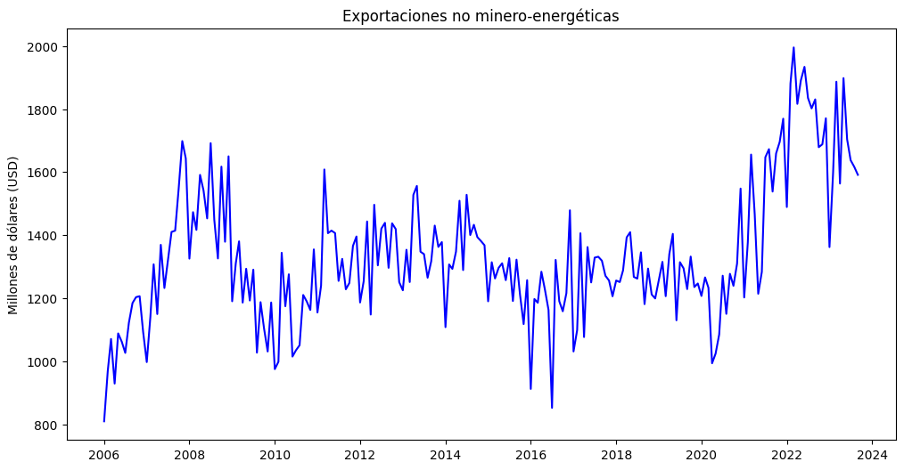

```python
# Gráfico de las exportaciones
plt.figure(figsize=(12, 6))
plt.plot(df.index, df['Expo_NME']/1000000, label='Graph1', color = 'blue')
plt.title('Exportaciones no minero-energéticas')
plt.ylabel('Millones de dólares (USD)')

# Guardar gráfico
# Crear una carpeta llamada 'graficos' si no existe
if not os.path.exists('Resultados'): os.makedirs('Resultados')

plt.savefig('Resultados\Exportaciones.png', dpi=300)
plt.show()
```

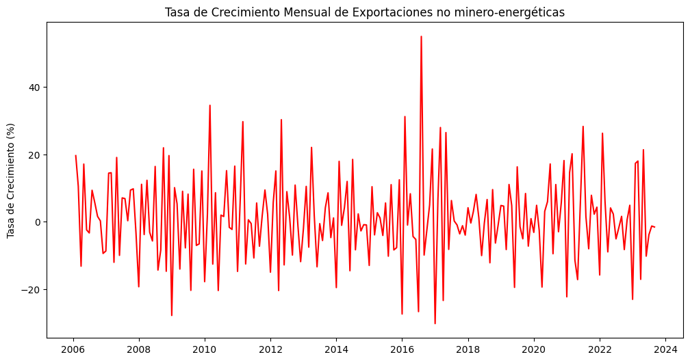

```python
# Gráfico de la tasa de variación de las exportaciones
# Calcular la tasa de crecimiento mensual
df['Tasa_Crecimiento'] = df['Expo_NME'].pct_change() * 100

# Gráfico
plt.figure(figsize=(12, 6))
plt.plot(df.index, df['Tasa_Crecimiento'], label='Graph2', color='red')
plt.title('Tasa de Crecimiento Mensual de Exportaciones no minero-energéticas')
plt.ylabel('Tasa de Crecimiento (%)')

# Guardar gráfico
plt.savefig('Resultados\Tasa de crecimiento mensual.png', dpi=300)
plt.show()
```

```python
# Estadísticas descriptivas de la tasa de crecimiento por año
stats_descriptivas_tasa_por_año = df.groupby(df.index.year)['Tasa_Crecimiento'].agg(['count', 'mean', 'min', 'max'])
print(stats_descriptivas_tasa_por_año)
```

```
      count  mean    min   max
Mes
2006     11  3.23 -13.21 19.63
2007     12  3.95 -12.06 19.08
2008     12  0.99 -19.32 21.96
2009     12 -1.70 -27.85 15.58
2010     12  2.16 -20.44 34.57
2011     12  0.88 -14.76 29.72
2012     12  0.07 -20.45 30.31
2013     12  1.20 -13.40 22.07
2014     12  0.57 -19.57 18.51
2015     12 -0.34 -12.99 12.45
2016     12  3.65 -27.42 55.04
2017     12 -0.34 -30.27 27.98
2018     12  0.17 -12.20  9.54
2019     12  0.77 -19.51 16.29
2020     12  2.36 -19.42 18.17
2021     12  2.15 -22.31 28.30
2022     12  0.48 -15.83 26.28
2023      9 -0.04 -23.06 21.38
```

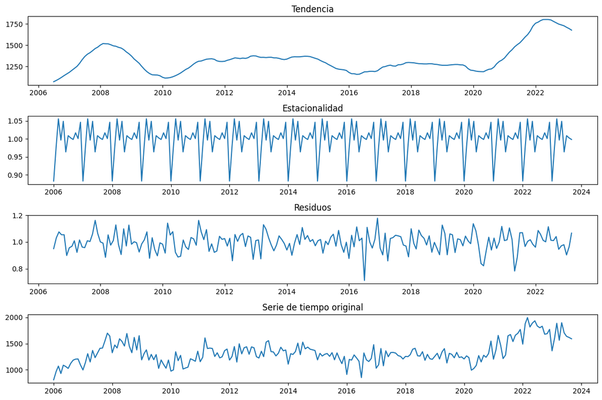

```python
# Decomposición de la serie temporal
decomp = seasonal_decompose(df['Expo_NME'], model='multiplicative', period=12)

# Gráfico de la descomposición
plt.figure(figsize=(12, 8))

plt.subplot(4, 1, 1)
plt.plot(decomp.trend/1000000)
plt.title('Tendencia')

plt.subplot(4, 1, 2)
plt.plot(decomp.seasonal)
plt.title('Estacionalidad')

plt.subplot(4, 1, 3)
plt.plot(decomp.resid)
plt.title('Residuos')

plt.subplot(4, 1, 4)
plt.plot(df.index, df['Expo_NME']/1000000, label='TS_Original')
plt.title('Serie de tiempo original')


# Guardar gráfico
plt.savefig('Resultados\Decomposición serie de tiempo.png', dpi=300)
plt.tight_layout()
plt.show()

# Se observa una estacionalidad marcada en la serie de exportaciones.
```

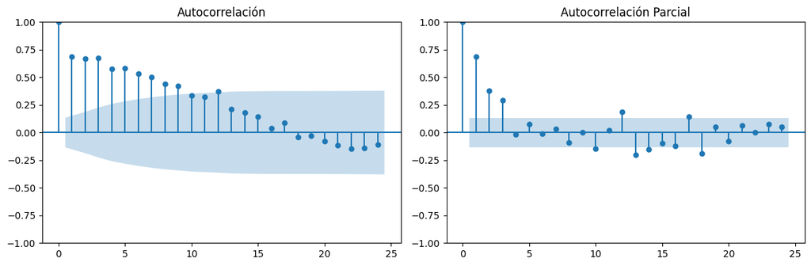

```python
# Autocorrelación y Autocorrelación Parcial
plt.figure(figsize=(12, 4))

# Autocorrelación
plt.subplot(1, 2, 1)
plot_acf(df['Expo_NME'], lags=24, ax=plt.gca(), title='Autocorrelación')

# Autocorrelación Parcial
plt.subplot(1, 2, 2)
plot_pacf(df['Expo_NME'], lags=24, ax=plt.gca(), title='Autocorrelación Parcial')

# Guardar gráfico
plt.savefig('Resultados\Autocorrelación y Autocorrelación Parcial.png', dpi=300)
plt.tight_layout()
plt.show()

# Se observa que la serie podría se suceptible a ser modelada con un proceso ARIMA con 8 rezagos en un parte AR y 3 en su parte MA
```

### Creación de conjuntos de entrenamiento y prueba

```python
# Fechas de los conjuntos
fecha_final_train = '2022-12-31'
fecha_inicio_test = '2023-01-01'
fecha_final_test = '2023-09-30'

# Creación de conjuntos
train = df.loc[df.index <= fecha_final_train]
test = df.loc[(df.index >= fecha_inicio_test) & (df.index <= fecha_final_test)]
```

```python
train
```

| Mes | Expo_NME | Fecha | Tasa_Crecimiento |
| --- | --- | --- | --- |
| 2006-01-01 | 810133312.30 | Jan-06 | NaN |
| 2006-02-01 | 969127002.92 | Feb-06 | 19.63 |
| 2006-03-01 | 1071191991.02 | Mar-06 | 10.53 |
| 2006-04-01 | 929687981.83 | Apr-06 | -13.21 |
| 2006-05-01 | 1088814132.41 | May-06 | 17.12 |
| ... | ... | ... | ... |
| 2022-08-01 | 1802275652.71 | Aug-22 | -1.80 |
| 2022-09-01 | 1830876109.08 | Sep-22 | 1.59 |
| 2022-10-01 | 1679259081.30 | Oct-22 | -8.28 |
| 2022-11-01 | 1688456395.86 | Nov-22 | 0.55 |
| 2022-12-01 | 1770937816.63 | Dec-22 | 4.89 |

204 rows × 3 columns

```python
test
```

| Mes | Expo_NME | Fecha | Tasa_Crecimiento |
| --- | --- | --- | --- |
| 2023-01-01 | 1362510517.58 | Jan-23 | -23.06 |
| 2023-02-01 | 1598769082.98 | Feb-23 | 17.34 |
| 2023-03-01 | 1886930761.37 | Mar-23 | 18.02 |
| 2023-04-01 | 1563917296.69 | Apr-23 | -17.12 |
| 2023-05-01 | 1898317953.70 | May-23 | 21.38 |
| 2023-06-01 | 1704195433.57 | Jun-23 | -10.23 |
| 2023-07-01 | 1638096877.49 | Jul-23 | -3.88 |
| 2023-08-01 | 1617054048.21 | Aug-23 | -1.28 |
| 2023-09-01 | 1591565181.66 | Sep-23 | -1.58 |

## 4.1. ARIMA y SARIMA

```python
# Prueba de raíz unitaria a la serie completa: Dickey-Fuller aumentada con criterio de información de AIC
adf = adfuller(df['Expo_NME'], autolag='AIC')

# Resultados
print(f'Estadística ADF: {adf[0]}')
print(f'P-valor: {adf[1]}')
print(f'Valores críticos: {adf[4]}')
print(f'Resultado: La serie es {"estacionaria" if adf[1] <= 0.05 else "no estacionaria"}\n')
```

```
Estadística ADF: -3.239222483225714
P-valor: 0.017823662136085293
Valores críticos: {'1%': -3.463987334463603, '5%': -2.8763259091636213, '10%': -2.5746515171738515}
Resultado: La serie es estacionaria
```

```python
# Prueba de raíz unitaria al componente estacional: Dickey-Fuller aumentada con criterio de información de AIC
adf_seasonal = adfuller(decomp.seasonal.dropna(), autolag='AIC')

# Resultados
print(f'Estadística ADF: {adf_seasonal[0]}')
print(f'P-valor: {adf_seasonal[1]}')
print(f'Valores críticos: {adf_seasonal[4]}')
print(f'Resultado: La serie es {"estacionaria" if adf_seasonal[1] <= 0.05 else "no estacionaria"}\n')
```

```
Estadística ADF: -103434022893706.05
P-valor: 0.0
Valores críticos: {'1%': -3.4633090972761744, '5%': -2.876029332045744, '10%': -2.5744932593252643}
Resultado: La serie es estacionaria
```

Ya que la serie es estacionaria en niveles y su componente estacional también, se puede estimar los modelos ARIMA(p,0,q) y SARIMA(p,0,1)(P,0,Q).

```python
# Selección autmática de rezagos en base a AIC
auto_arima = auto_arima(train['Expo_NME'], seasonal=True, m=12, trace = True)
```

```
Performing stepwise search to minimize aic
 ARIMA(2,1,2)(1,0,1)[12] intercept   : AIC=8184.366, Time=0.77 sec
 ARIMA(0,1,0)(0,0,0)[12] intercept   : AIC=8253.042, Time=0.02 sec
 ARIMA(1,1,0)(1,0,0)[12] intercept   : AIC=8198.305, Time=0.08 sec
 ARIMA(0,1,1)(0,0,1)[12] intercept   : AIC=8181.687, Time=0.09 sec
 ARIMA(0,1,0)(0,0,0)[12]             : AIC=8251.220, Time=0.02 sec
 ARIMA(0,1,1)(0,0,0)[12] intercept   : AIC=8196.600, Time=0.04 sec
 ARIMA(0,1,1)(1,0,1)[12] intercept   : AIC=8183.558, Time=0.18 sec
 ARIMA(0,1,1)(0,0,2)[12] intercept   : AIC=8183.686, Time=0.18 sec
 ARIMA(0,1,1)(1,0,0)[12] intercept   : AIC=8183.609, Time=0.08 sec
 ARIMA(0,1,1)(1,0,2)[12] intercept   : AIC=inf, Time=0.77 sec
 ARIMA(0,1,0)(0,0,1)[12] intercept   : AIC=8240.127, Time=0.10 sec
 ARIMA(1,1,1)(0,0,1)[12] intercept   : AIC=8183.243, Time=0.11 sec
 ARIMA(0,1,2)(0,0,1)[12] intercept   : AIC=8183.529, Time=0.11 sec
 ARIMA(1,1,0)(0,0,1)[12] intercept   : AIC=8197.849, Time=0.08 sec
 ARIMA(1,1,2)(0,0,1)[12] intercept   : AIC=inf, Time=0.49 sec
 ARIMA(0,1,1)(0,0,1)[12]             : AIC=8180.475, Time=0.10 sec
 ARIMA(0,1,1)(0,0,0)[12]             : AIC=8195.586, Time=0.03 sec
 ARIMA(0,1,1)(1,0,1)[12]             : AIC=8182.475, Time=0.32 sec
 ARIMA(0,1,1)(0,0,2)[12]             : AIC=8182.475, Time=0.35 sec
 ARIMA(0,1,1)(1,0,0)[12]             : AIC=8181.446, Time=0.17 sec
 ARIMA(0,1,1)(1,0,2)[12]             : AIC=inf, Time=0.85 sec
 ARIMA(0,1,0)(0,0,1)[12]             : AIC=8237.697, Time=0.06 sec
 ARIMA(1,1,1)(0,0,1)[12]             : AIC=8182.191, Time=0.11 sec
 ARIMA(0,1,2)(0,0,1)[12]             : AIC=8182.139, Time=0.09 sec
 ARIMA(1,1,0)(0,0,1)[12]             : AIC=8196.241, Time=0.05 sec
 ARIMA(1,1,2)(0,0,1)[12]             : AIC=inf, Time=0.79 sec

Best model:  ARIMA(0,1,1)(0,0,1)[12]
Total fit time: 6.065 seconds
```

```python
#  Parámetros óptimos encontrados
print(auto_arima.order)
print(auto_arima.seasonal_order)
```

```
(0, 1, 1)
(0, 0, 1, 12)
```

```python
# Modelo ARIMA
arima = ARIMA(train['Expo_NME'], order=(0,0,1))
sarima = ARIMA(train['Expo_NME'], order=(0,0,1), seasonal_order = (0, 0, 1, 12))
```

[output not shown]

```python
# Predicciones en el conjunto de validación:
pred_arima = arima.fit().get_forecast(steps=len(test))
pred_sarima = sarima.fit().get_forecast(steps=len(test))
```

```python
# Medidas de error
# Error absoluto medio (MAE)
mae_arima = mean_absolute_error(test['Expo_NME'], pred_arima.predicted_mean)
mae_sarima = mean_absolute_error(test['Expo_NME'], pred_sarima.predicted_mean)

# Error cuadrático medio (MSE)
mse_arima = mean_squared_error(test['Expo_NME'], pred_arima.predicted_mean)
mse_sarima = mean_squared_error(test['Expo_NME'], pred_sarima.predicted_mean)

# Error cuadrático medio de la raíz (RMSE)
rmse_arima = math.sqrt(mse_arima)
rmse_sarima = math.sqrt(mse_sarima)
```

## 4.2. Algoritmo de Suavizado exponencial triple (ETS)

```python
# Modelo ETS
ets = ExponentialSmoothing(train['Expo_NME'], trend='add', seasonal='add', seasonal_periods=12)
```

```
C:\Users\Nicolás Rivera\AppData\Roaming\Python\Python38\site-packages\statsmodels\tsa\base\tsa_model.py:473: ValueWarning: No frequency information was provided, so inferred frequency MS will be used.
  self._init_dates(dates, freq)
```

```python
# Predicciones en el conjunto de validación:
pred_ets = ets.fit().forecast(steps=len(test))
```

```
C:\Users\Nicolás Rivera\AppData\Roaming\Python\Python38\site-packages\statsmodels\tsa\holtwinters\model.py:917: ConvergenceWarning: Optimization failed to converge. Check mle_retvals.
  warnings.warn(
```

```python
# Medidas de error
# Error absoluto medio (MAE)
mae_ets = mean_absolute_error(test['Expo_NME'], pred_ets)

# Error cuadrático medio (MSE)
mse_ets = mean_squared_error(test['Expo_NME'], pred_ets)

# Error cuadrático medio de la raíz (RMSE)
rmse_ets = math.sqrt(mse_ets)
```

## 4.3. Prophet

```python
# Crear los datos en el formato requerido
prophet_train = pd.DataFrame({'ds': train.index, 'y': train['Expo_NME']})
```

```python
# Inicializar el modelo Prophet
modelo_prophet = Prophet()

# Ajustar el modelo con los datos de entrenamiento
modelo_prophet.fit(prophet_train)
```

```
20:40:24 - cmdstanpy - INFO - Chain [1] start processing
20:40:24 - cmdstanpy - INFO - Chain [1] done processing
```

```
<prophet.forecaster.Prophet at 0x24966587dc0>
```

```python
# Crear un DataFrame para las fechas de prueba
fechas_test = pd.date_range(start=fecha_inicio_test, end=fecha_final_test, freq='M')
prophet_test = pd.DataFrame({'ds': fechas_test})

# Realizar predicciones para las fechas de prueba
predicciones_prophet = modelo_prophet.predict(prophet_test)
pred_prophet = predicciones_prophet['yhat'].values

# Valores reales de test
valores_reales = test['Expo_NME'].values
```

```python
# Medidas de error
# Error absoluto medio (MAE)
mae_prophet = np.mean(np.abs(valores_reales - pred_prophet))

# Error cuadrático medio (MSE)
mse_prophet = np.mean((valores_reales - pred_prophet)**2)

# Error cuadrático medio de la raíz (RMSE)
rmse_prophet = math.sqrt(mse_prophet)
```

## 4.4. XGBoost

```python
# Creación de características:
df['Trimestre'] = df.index.quarter
df['Mes'] = df.index.month
df['Año'] = df.index.year
```

```python
# Fechas de los conjuntos
fecha_final_train = '2022-12-31'
fecha_inicio_test = '2023-01-01'
fecha_final_test = '2023-09-30'

# Creación de conjuntos
train = df.loc[df.index <= fecha_final_train]
test = df.loc[(df.index >= fecha_inicio_test) & (df.index <= fecha_final_test)]
```

```python
# Nombres para x y y
X = ['Trimestre', 'Mes', 'Año']
Y = 'Expo_NME'

# Conjuntos XGBOOST
X_train = train[X]
y_train = train[Y]

X_test = test[X]
y_test = test[Y]
```

```python
xgb_model = XGBRegressor(base_score=0.5, booster='gbtree',
                       n_estimators=1000,
                       early_stopping_rounds=50,
                       objective='reg:squarederror',
                       max_depth=3,
                       learning_rate=0.01)
xgb_model.fit(X_train, y_train,
        eval_set=[(X_train, y_train), (X_test, y_test)],
        verbose=100)
```

```
XGBRegressor(base_score=0.5, booster='gbtree', callbacks=None,
             colsample_bylevel=None, colsample_bynode=None,
             colsample_bytree=None, device=None, early_stopping_rounds=50,
             enable_categorical=False, eval_metric=None, feature_types=None,
             gamma=None, grow_policy=None, importance_type=None,
             interaction_constraints=None, learning_rate=0.01, max_bin=None,
             max_cat_threshold=None, max_cat_to_onehot=None,
             max_delta_step=None, max_depth=3, max_leaves=None,
             min_child_weight=None, missing=nan, monotone_constraints=None,
             multi_strategy=None, n_estimators=1000, n_jobs=None,
             num_parallel_tree=None, random_state=None, ...)
```

```python
pred_xgb = xgb_model.predict(X_test)
```

```python
# Medidas de error
# Error absoluto medio (MAE)
mae_xgb = mean_absolute_error(test['Expo_NME'], pred_xgb)

# Error cuadrático medio (MSE)
mse_xgb = mean_squared_error(test['Expo_NME'], pred_xgb)

# Error cuadrático medio de la raíz (RMSE)
rmse_xgb = math.sqrt(mse_xgb)
```

## 5. Medidas de precisión y comparación de pronósticos

```python
data = {
    'Modelo': ['ARIMA', 'SARIMA', 'ETS', 'Prophet', 'XGBoost'],
    'MAE': [mae_arima, mae_sarima, mae_ets, mae_prophet, mae_xgb],
    'MSE': [mse_arima, mse_sarima, mse_ets, mse_prophet, mse_xgb],
    'RMSE': [rmse_arima, rmse_sarima, rmse_ets, rmse_prophet, rmse_xgb]
}

df_resultados = pd.DataFrame(data)

# Mostrar la tabla de resultados
print(df_resultados)
```

```
    Modelo          MAE                   MSE         RMSE
0    ARIMA 339316505.96 135283363217778832.00 367808867.78
1   SARIMA 161227520.76  35688081329404308.00 188912893.50
2      ETS 119578393.94  16815331767262250.00 129673944.06
3  Prophet 163529337.90  33240953205657296.00 182321016.91
4  XGBoost 100226760.00  13990704586258424.00 118282308.85
```

```python
# Conjunto de entrenamiento modelo final
train = df[['Expo_NME', 'Fecha', 'Tasa_Crecimiento', 'Trimestre', 'Mes', 'Año']]
```

```python
# Nombres para x y y
X = ['Trimestre', 'Mes', 'Año']
Y = 'Expo_NME'

# Conjuntos XGBOOST
X_train = train[X]
y_train = train[Y]
```

```python
# Modelo final
xgb_model_final = XGBRegressor(base_score=0.5, booster='gbtree',
                       n_estimators=5000,
                       objective='reg:squarederror',
                       max_depth=5,
                       learning_rate=0.05)
xgb_model_final.fit(X_train, y_train,verbose=100)
```

```
XGBRegressor(base_score=0.5, booster='gbtree', callbacks=None,
             colsample_bylevel=None, colsample_bynode=None,
             colsample_bytree=None, device=None, early_stopping_rounds=None,
             enable_categorical=False, eval_metric=None, feature_types=None,
             gamma=None, grow_policy=None, importance_type=None,
             interaction_constraints=None, learning_rate=0.05, max_bin=None,
             max_cat_threshold=None, max_cat_to_onehot=None,
             max_delta_step=None, max_depth=5, max_leaves=None,
             min_child_weight=None, missing=nan, monotone_constraints=None,
             multi_strategy=None, n_estimators=5000, n_jobs=None,
             num_parallel_tree=None, random_state=None, ...)
```

```python
# Fechas futuras de pronósticos
fechas_futuras = pd.date_range(start='2023-10-01', end='2024-12-31', freq='M')

# Crear DataFrame con las fechas futuras
df_futuro = pd.DataFrame(index=fechas_futuras)

# Agregar las características adicionales (Trimestre, Mes, Año)
df_futuro['Trimestre'] = df_futuro.index.quarter
df_futuro['Mes'] = df_futuro.index.month
df_futuro['Año'] = df_futuro.index.year
```

```python
# Realizar predicciones para las fechas futuras
predicciones_futuras = xgb_model_final.predict(df_futuro[X])

# Agregar las predicciones al DataFrame futuro
df_futuro['Predicciones'] = predicciones_futuras
```

```python
df_futuro
```

|  | Trimestre | Mes | Año | Predicciones |
| --- | --- | --- | --- | --- |
| 2023-10-31 | 4 | 10 | 2023 | 1586363392.00 |
| 2023-11-30 | 4 | 11 | 2023 | 1594597120.00 |
| 2023-12-31 | 4 | 12 | 2023 | 1672032768.00 |
| 2024-01-31 | 1 | 1 | 2024 | 1362508032.00 |
| 2024-02-29 | 1 | 2 | 2024 | 1598773120.00 |
| 2024-03-31 | 1 | 3 | 2024 | 1886930688.00 |
| 2024-04-30 | 2 | 4 | 2024 | 1563919232.00 |
| 2024-05-31 | 2 | 5 | 2024 | 1898317312.00 |
| 2024-06-30 | 2 | 6 | 2024 | 1704198272.00 |
| 2024-07-31 | 3 | 7 | 2024 | 1638095744.00 |
| 2024-08-31 | 3 | 8 | 2024 | 1617049728.00 |
| 2024-09-30 | 3 | 9 | 2024 | 1591566592.00 |
| 2024-10-31 | 4 | 10 | 2024 | 1586363392.00 |
| 2024-11-30 | 4 | 11 | 2024 | 1594597120.00 |
| 2024-12-31 | 4 | 12 | 2024 | 1672032768.00 |

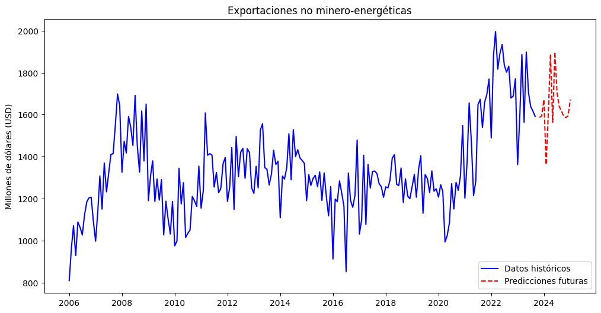

```python
# Graficar las predicciones
plt.figure(figsize=(12, 6))
plt.plot(df.index, df['Expo_NME']/1000000, label='Datos históricos', color='blue')
plt.plot(df_futuro.index, df_futuro['Predicciones']/1000000, label='Predicciones futuras', color='red', linestyle='--')
plt.title('Exportaciones no minero-energéticas')
plt.ylabel('Millones de dólares (USD)')
plt.legend(loc='lower right')
plt.savefig('Resultados\Pronósticos.png', dpi=300)
plt.show()
```

```python
# Exportar resultados de la predicción:
df_futuro.to_excel('Resultados\Predicciones - NME.xlsx', index=True)
```